# Coursera - Reproducible Research - Assignment 2

Identifying the most destructive weather events across the USA

Ron Ammar

```r
  # Clear the current session, to avoid errors from persisting data structures
  rm(list=ls())

  # Free up memory by forcing garbage collection
  invisible(gc())

  # Pretty printing in knitr
  library(printr)

  # Manually set the seed to an arbitrary number for consistency in reports
  set.seed(1234)

  # Do not convert character vectors to factors unless explicitly indicated
  options(stringsAsFactors=FALSE)

  startTime <- Sys.time()

  library(dplyr)
  library(choroplethr)
  library(choroplethrMaps)
  library(ggplot2)
  library(gridExtra)
  library(randomcoloR)
  library(stringr)
```

## Background

Storms and other severe weather events can cause both public health and economic problems for communities and municipalities. Many severe events can result in fatalities, injuries, and property damage, and preventing such outcomes to the extent possible is a key concern.

This project involves exploring the U.S. National Oceanic and Atmospheric Administration’s (NOAA) storm database. This database tracks characteristics of major storms and weather events in the United States, including when and where they occur, as well as estimates of any fatalities, injuries, and property damage.

The events in the database start in the year 1950 and end in November 2011. In the earlier years of the database there are generally fewer events recorded, most likely due to a lack of good records. More recent years should be considered more complete.

## Purpose

The purpose of this analysis is to:

1. Complete the Reproducible Research course project #2.
2. Across the United States, determine which types of events are most harmful to population health?
3. Across the United States, which types of events have the greatest economic consequences?

## Data Processing

**Analysis Date:** 1:18:09, Tuesday, March 01, 2016

*Describes how the data were loaded into R and processed for analysis?*

```r
  ##### This knitr chunk is cached to increase development speed.
  stormData <- read.csv(bzfile("data/repdata-data-StormData.csv.bz2"))
```

First, let’s process the storm data dates and times into R POSIX time. We will also parse the damages.

```r
  ##### This knitr chunk is cached to increase development speed.

  # Add the time to the date and format as POSIX time
  stormData$BGN_DATE <- str_replace(stormData$BGN_DATE, "\\s.+", "")
  dates <- strptime(stormData$BGN_DATE, format="%m/%d/%Y")
  stormData$MONTH <- factor(months(dates), levels=month.name)
  stormData$YEAR <- dates$year + 1900

  # EXPLORATORY: figure out which symbols are used to define the cost magnitude
  # count(stormData, CROPDMGEXP)
  # count(stormData, PROPDMGEXP)

  # Compute the cost and multiple by correct factor/exponent
  expLookup <- list(h=2, H=2, k=3, K=3, m=6, M=6, B=9)

  computeDamages <- function(damage, damageExp) {
    # Precondition: damage and damageExp have the same length
    output <- vector(mode="numeric", length=length(damage))
    for (i in 1:length(damage)) {
      # Determine if damageExp is an allowed character or integer
      num <- suppressWarnings(as.numeric(damageExp[i]))
      exponent <- 0  # if it doesn't fit into the categories, return the raw damages
      if (!is.na(num)) {
        exponent <- num
      } else if (damageExp[i] %in% names(expLookup)) {
        exponent <- expLookup[[damageExp[i]]]
      }

      output[i] <- damage[i] * 10 ^ exponent
    }

    return(output)
  }

  # Add to source table
  stormData <- mutate(stormData,
                      pDMG=computeDamages(PROPDMG, PROPDMGEXP),
                      cDMG=computeDamages(CROPDMG, CROPDMGEXP))
```

## Results

First, let’s examine the data. How many records do we have for each year in the database?

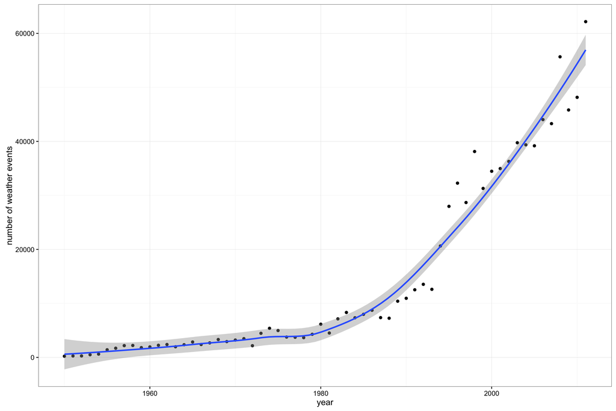

```r
  numEvents <- count(stormData, YEAR)
  ggplot(numEvents, aes(x=YEAR, y=n)) +
    geom_point() +
    stat_smooth() +
    labs(x="year", y="number of weather events") +
    theme_bw()
```

Since there are many more events on record in recent years, we will have to be aware of this trend. It may be due to changing weather patterns, increases in population, increases of measurement of weather events or a combination of these factors.

To get a sense of the time of year when storms are most dangerous, let’s take a look at how much destruction is attributed to storms in the US by month during the years of this survey.

```r
summary <- stormData %>%
  group_by(MONTH) %>%
  summarise(fatalities=sum(FATALITIES), injuries=sum(INJURIES),
            property_damage=sum(pDMG), crop_damage=sum(cDMG)) %>%
  mutate(property_damage=format(property_damage, scientific=TRUE, digits=2),
         crop_damage=format(crop_damage, scientific=TRUE, digits=2))

# Months with the highest total for fatalities, injuries, property or crop damages
maxF <- summary$MONTH[
  which(summary$fatalities == max(summary$fatalities))]
maxI <- summary$MONTH[
  which(summary$injuries == max(summary$injuries))]
maxP <- summary$MONTH[
  which(summary$property_damage == max(summary$property_damage))]
maxC <- summary$MONTH[
  which(summary$crop_damage == max(summary$crop_damage))]

summary
```

| MONTH | fatalities | injuries | property_damage | crop_damage |
| --- | --- | --- | --- | --- |
| January | 895 | 5412 | 1.2e+11 | 2.4e+09 |
| February | 872 | 9305 | 4.4e+09 | 5.7e+09 |
| March | 1232 | 11676 | 1.9e+10 | 1.2e+09 |
| April | 2199 | 31426 | 2.9e+10 | 1.2e+09 |
| May | 1833 | 20267 | 3.4e+10 | 2.0e+09 |
| June | 1476 | 14809 | 2.3e+10 | 6.1e+09 |
| July | 2900 | 12267 | 1.3e+10 | 5.2e+09 |
| August | 1440 | 9598 | 9.8e+10 | 1.3e+10 |
| September | 762 | 4255 | 4.8e+10 | 6.2e+09 |
| October | 406 | 9825 | 2.5e+10 | 2.3e+09 |
| November | 518 | 6797 | 6.1e+09 | 9.0e+08 |
| December | 612 | 4891 | 6.1e+09 | 3.1e+09 |

### Where is the most damage occurring?

Here we show a map with the total weather-related incidents from 1950 to 2011.

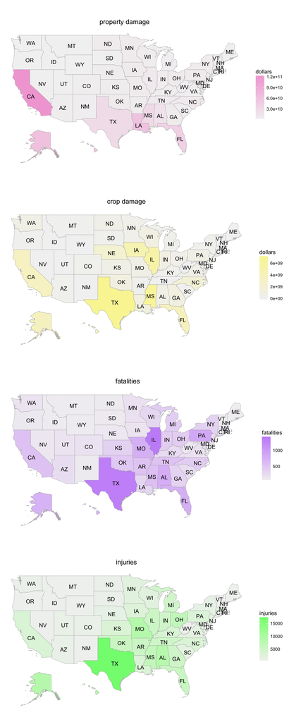

```r
  # Let's prepare the table for use with the map package by adding state regions
  data(state.regions)
  regionLookup <- select(state.regions, region, abb)
  stormData <- left_join(stormData, regionLookup, by=c("STATE" = "abb"))

  # Function to draw maps
  renderMap <- function(df, title, legendTitle="", numColors=1) {
    choro <- StateChoropleth$new(df)
    choro$title <- title
    choro$set_num_colors(numColors)
    if (numColors == 1) {
      choro$ggplot_scale <- scale_fill_continuous(
        name=legendTitle, low="gray95", high=randomColor(luminosity="light"))
    } else if (numColors > 1) {
      choro$ggplot_scale <- scale_fill_manual(
        name=legendTitle, values=unname(distinctColorPalette(numColors)), drop=FALSE)
    }
    return(choro$render())
  }

  totalPropertyDamage <- stormData %>%
    group_by(region) %>%
    summarise(value=sum(pDMG))
  p1 <- renderMap(totalPropertyDamage, "property damage", "dollars")

  totalCropDamage <- stormData %>%
    group_by(region) %>%
    summarise(value=sum(cDMG))
  p2 <- renderMap(totalCropDamage, "crop damage", "dollars")

  totalFatalities <- stormData %>%
    group_by(region) %>%
    summarise(value=sum(FATALITIES))
  p3 <- renderMap(totalFatalities, "fatalities", "fatalities")

  totalInjuries <- stormData %>%
    group_by(region) %>%
    summarise(value=sum(INJURIES))
  p4 <- renderMap(totalInjuries, "injuries", "injuries")

  grid.arrange(p1, p2, p3, p4, nrow=4)
```

### Which events are the most dangerous across the USA?

Questions: *Which types of events are most harmful to population health?* *Which types of events have the greatest economic consequences?*

Since there are no broad categories of natural disaster/weather events in the database, we will use the ones provided by the Department of Homeland Security on their [natural disasters website](https://www.ready.gov/natural-disasters).

This is a generalization. Many events such as fog or dust storms may not fall into these broader categories, but this is acceptable for this assignment.

```r
naturalDisasters <- list(
    drought=c("drought"),
    earthquake=c("quake"),
    "extreme heat"=c("heat", "hot", "warm"),
    flood=c("flood", "surf"),
    hurricane=c("hurricane"),
    landslide=c("landslide", "debris"),
    "space weather"=c("space", "solar"),
    "thunder/lightning"=c("thunder", "lightning", "wind", "rain"),
    tornado=c("tornado", "spout", "whirl", "funnel", "burst"),
    tsunami=c("tsunami"),
    volcano=c("volcano", "lava", "ash"),
    wildfire=c("fire"),
    "winter storm"=c("winter", "ice", "snow", "cold", "freeze", "hail", "blizzard",
                     "chill")
    )

  # For convenience, let's convert this to a named vector. The following code
  # allows the vector to have duplicate names. I'm also swapping the value and
  # names (names will be unique).
  naturalDisasters <- setNames(
    rep(names(naturalDisasters), lengths(naturalDisasters)),
    unlist(naturalDisasters, use.names=FALSE))

  getCategories <- function(weatherEvents) {
    allEvents <- tolower(weatherEvents)  # much faster than ignoring case in str_detect()
    output <- vector(mode="character", length=length(allEvents))
    for (i in 1:length(allEvents)) {
      output[i] <- "other"
      for (pattern in names(naturalDisasters)) {
        if (str_detect(allEvents[i], pattern)) {
          output[i] <- naturalDisasters[pattern]
          break
        }
      }
    }
    return(output)
  }

  # Now, let's add this broad category label to the data
  stormData$category <- getCategories(stormData$EVTYPE)
```

Now that we’ve assigned the Department of Homeland Security broad weather categories, we can investigate the extent of destruction of weather events across the US. Below, we summarize the events according to their devastating effects and show the weather event that caused the most amount of devastation based on the outcomes including fatalities, injuries, property damage or crop damage.

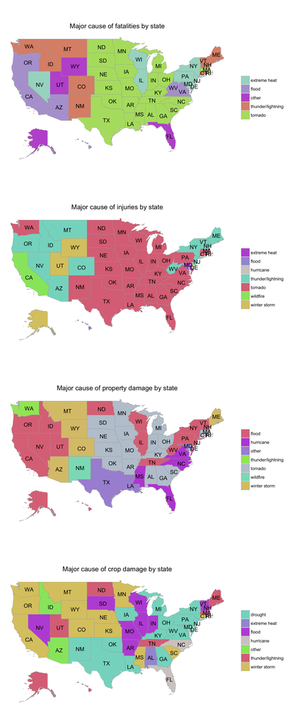

```r
  finalFigure <- stormData %>%
    group_by(region, category) %>%
    summarise(fatalities=sum(FATALITIES), injuries=sum(INJURIES),
            property_damage=sum(pDMG), crop_damage=sum(cDMG))

  # Now, we determine which event has the maximum effect for each of the 4
  # categories for each state. Ignore duplicates (South Dakota has the same
  # number of fatalities from tornadoes and winter storms)
  figF <- finalFigure %>%
    group_by(region) %>%
    filter(fatalities == max(fatalities)) %>%
    distinct() %>%
    select(region, category) %>%
    rename(value=category)

  p1 <- renderMap(figF, title="Major cause of fatalities by state",
            numColors=length(unique(figF$value)))

  figI <- finalFigure %>%
    group_by(region) %>%
    filter(injuries == max(injuries)) %>%
    distinct() %>%
    select(region, category) %>%
    rename(value=category)

  p2 <- renderMap(figI, title="Major cause of injuries by state",
            numColors=length(unique(figI$value)))

  figP <- finalFigure %>%
    group_by(region) %>%
    filter(property_damage == max(property_damage)) %>%
    distinct() %>%
    select(region, category) %>%
    rename(value=category)

  p3 <- renderMap(figP, title="Major cause of property damage by state",
            numColors=length(unique(figP$value)))

  figC <- finalFigure %>%
    group_by(region) %>%
    filter(crop_damage == max(crop_damage)) %>%
    distinct() %>%
    select(region, category) %>%
    rename(value=category)

  p4 <- renderMap(figC, title="Major cause of crop damage by state",
            numColors=length(unique(figC$value)))

  grid.arrange(p1, p2, p3, p4, nrow=4)
```

Since it’s late at night, I’m going to make a few quick observations: Injuries, fatalities and property damage are highest due to tornados in “Tornado Alley”. The largest crop/property damages in Florida are due to hurricanes. The most fatalities in Nevada are due to excessive heat. These all confirm general trends known about these states and their weather conditions.

## System Information

*Time required to process this report:* *40.43624 secs*